# Forecasting crime for strategic crime analysis

## But …

- We have only tested forecasts using data from one city
- We have only tested one scenario

## Many US cities make detailed crime data public

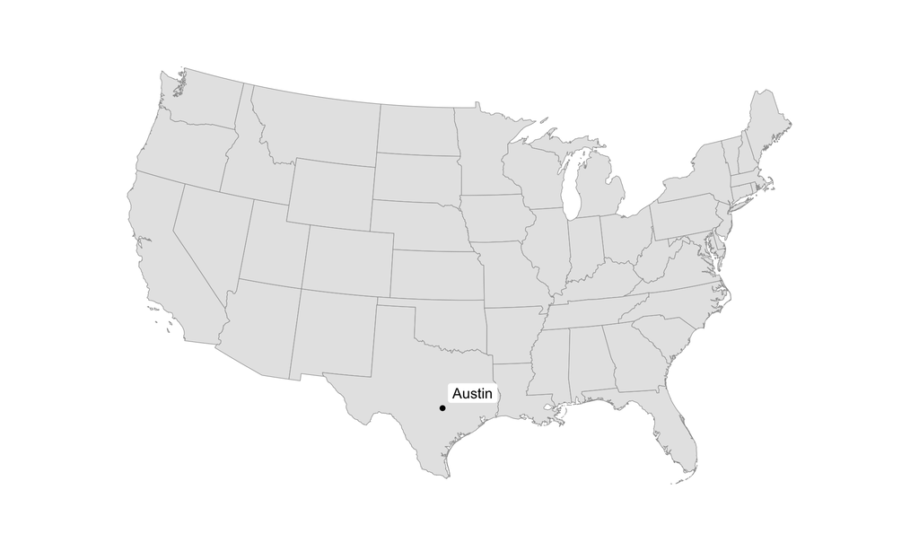

## Many US cities make detailed crime data public

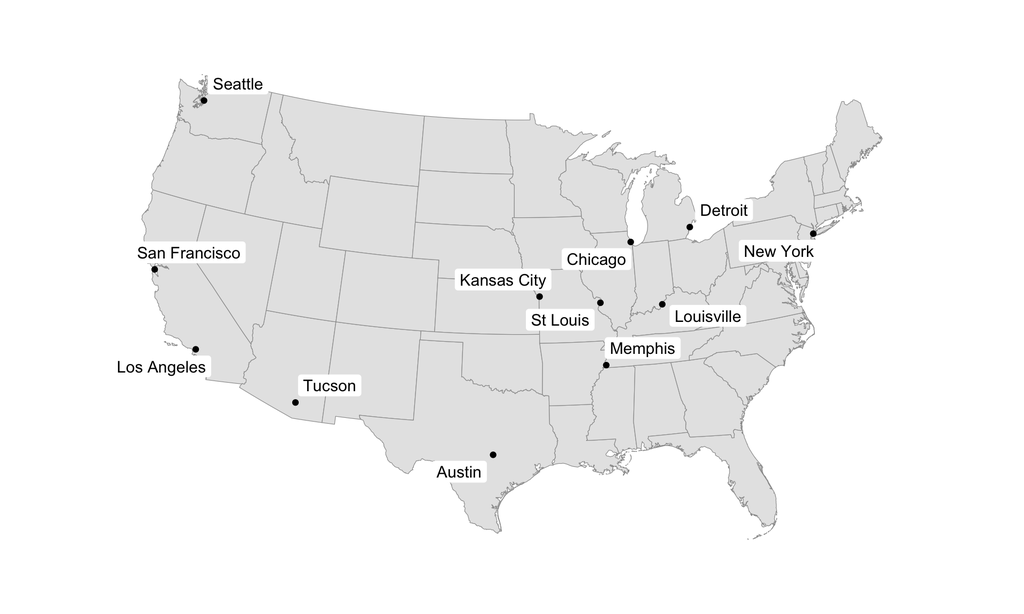

## It is also useful to test multiple realistic scenarios

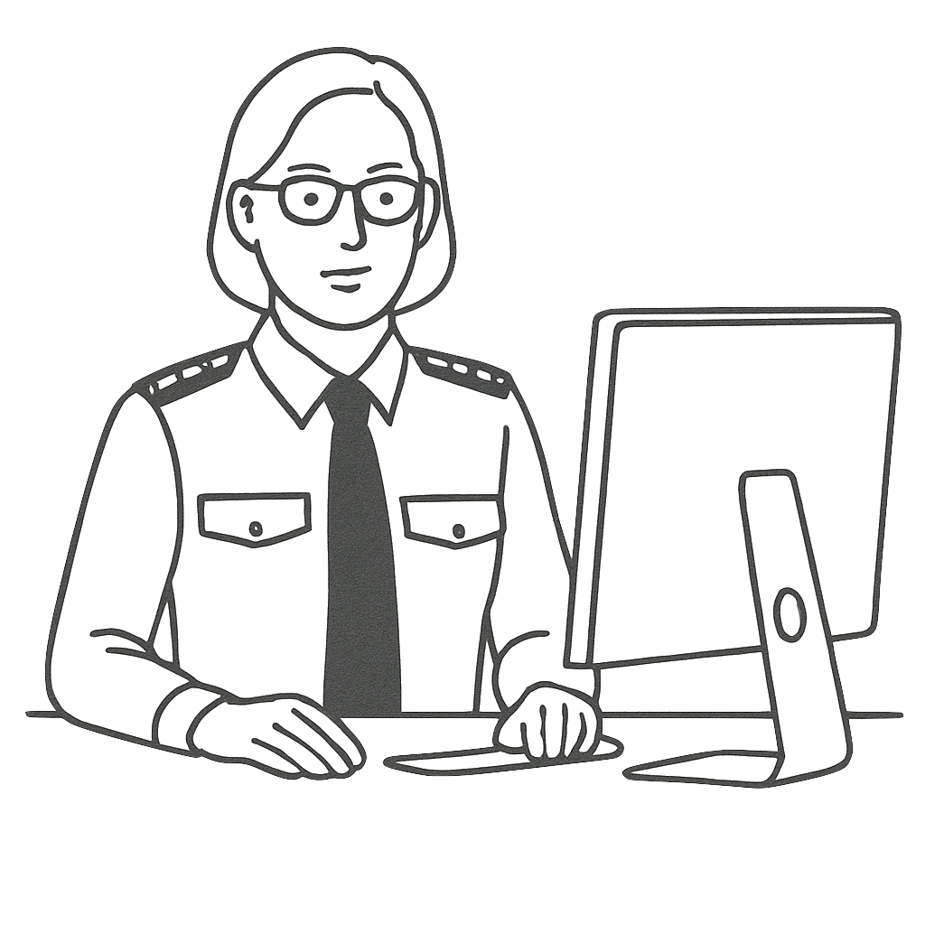

**Scenario 1**

how many crimes are likely to occur in a city each month for the next three years

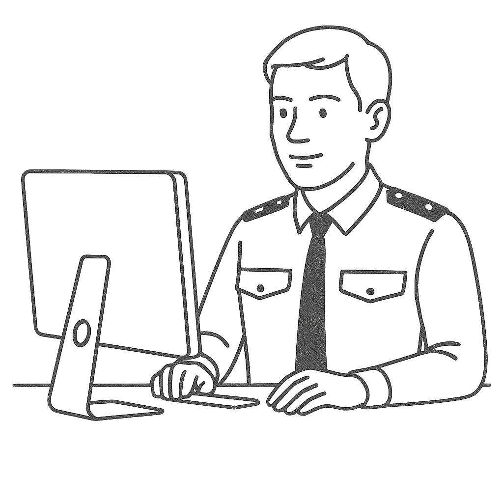

**Scenario 2**

how many crimes are likely to occur each day for the next three months.

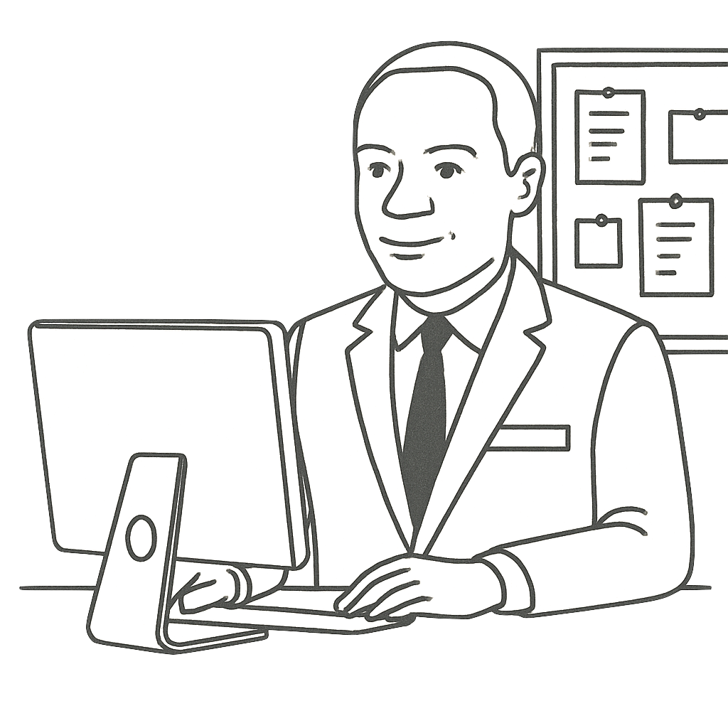

**Scenario 3**

36 rolling-origin forecasts for 3 scenarios in 12 cities each

⇒ 1,296 tests of the performance of each forecasting method

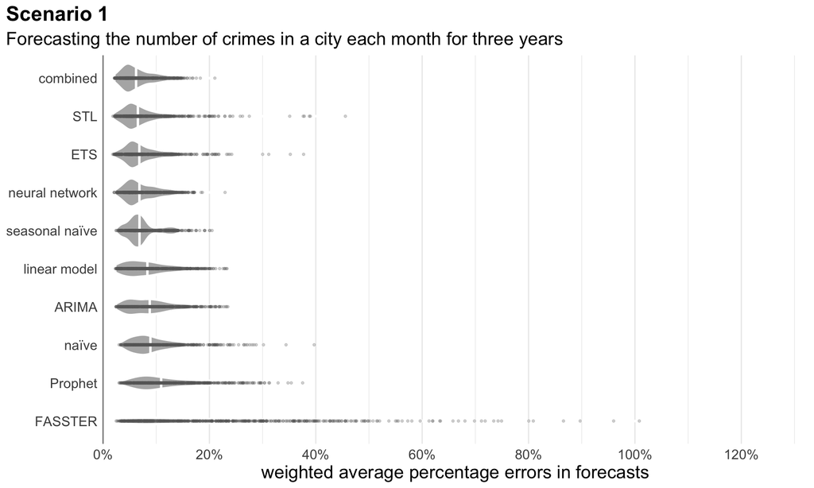

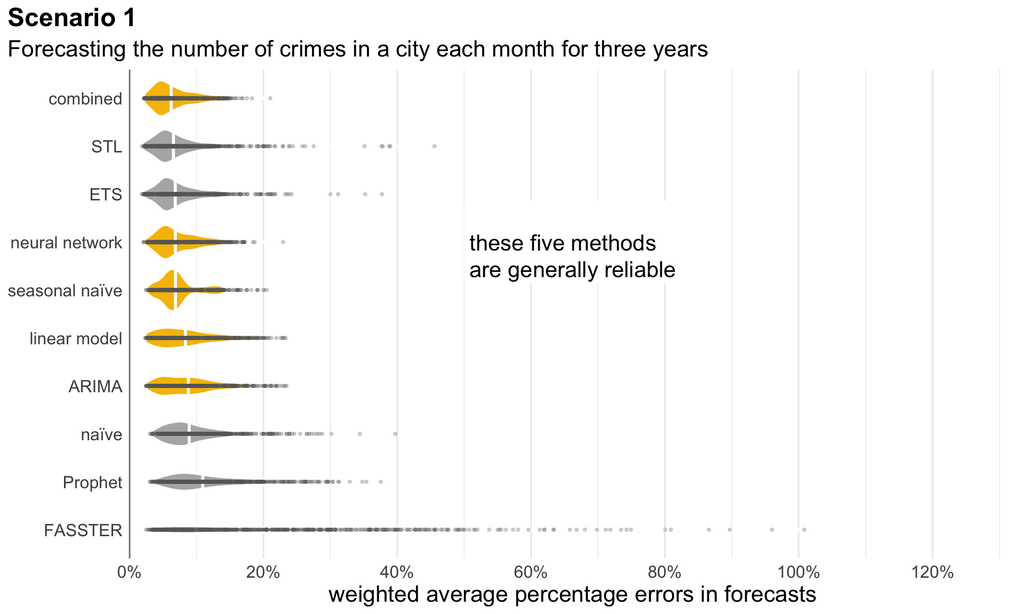

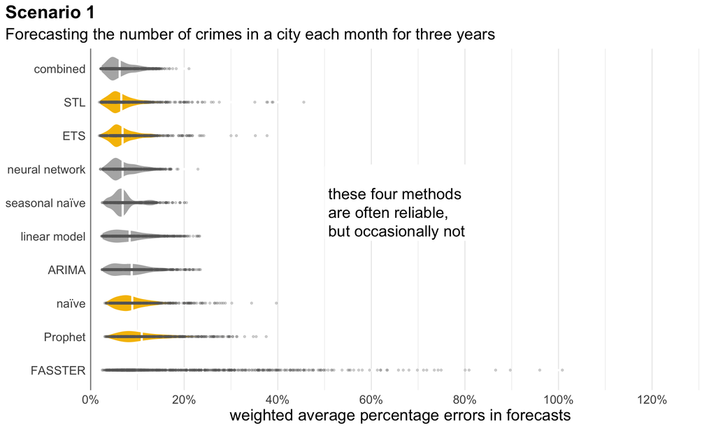

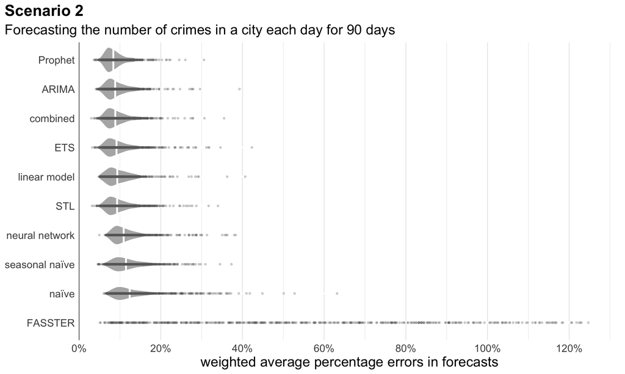

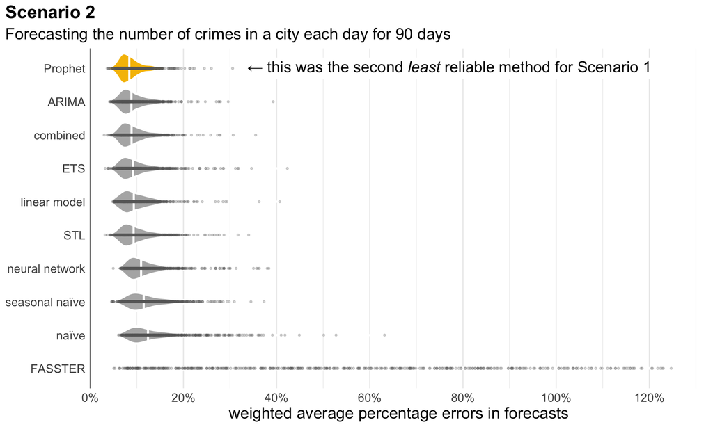

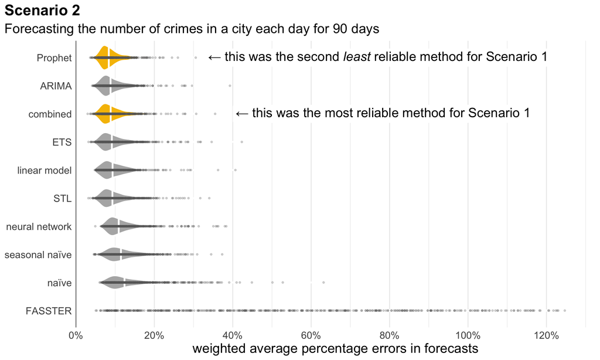

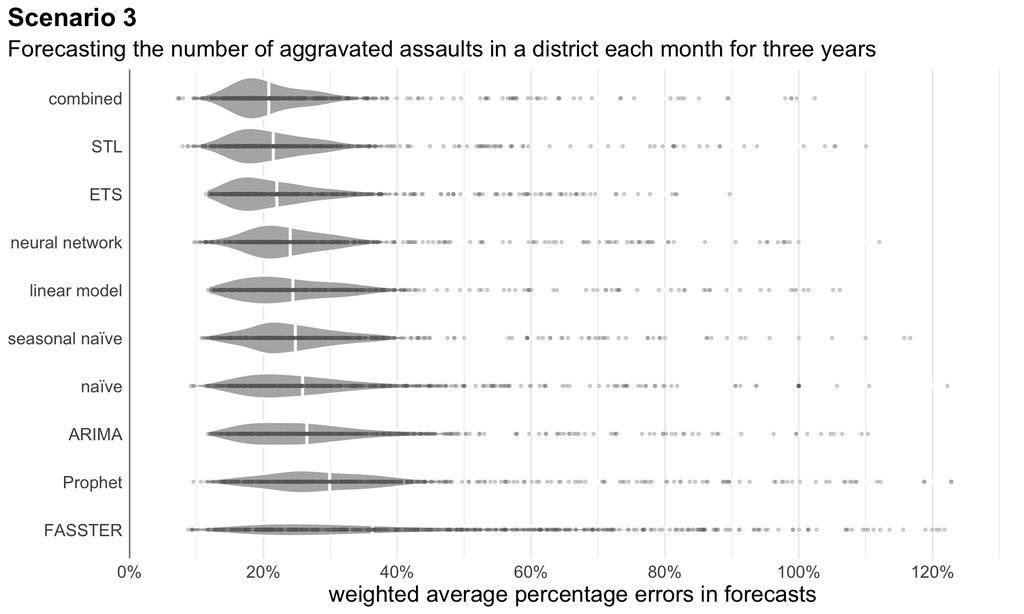

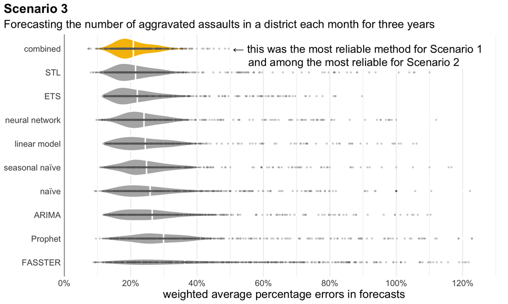

## Conclusion

- Reasonably accurate forecasting is possible
- Combining multiple forecasts is typically most accurate
- Method choice matters: some specific methods (e.g. FASSTER) are wildly inaccurate

**Remember**

Forecasts are only useful as long as there is structural stability

[figure not shown]

Slides:  
**lesscrime.info/talk/forecasting-scs-seminar/**

Questions:  
**matthew.ashby@ucl.ac.uk**